# Hands-On ANOVA in R

R Coding Club  
RTG 2660

Dr. Lea Hildebrandt

2024-04-30

# Repeated-Measures ANOVA

Often in our research, we have repeated measures: We collect more than one data point from each subject.

Advantage: increased power and precision.  
Disadvantage: violates **iid** (independent and identically distributed) assumption of *ordinary least squares* methods (regression, ANOVA).

- independent: probability of a data point taking on specific value is independent of of values taken by other data points.
- identically distributed: data points are samples from same underlying distribution.

Problem: Observations from the same subject are usually correlated (i.e. more likely to be similar to each other than to other observations).

–> this also applies to other forms of dependency: if units of observations are clustered, e.g. mice in cage/handled by experimenter, students in classroom…

In contrast to violations of other assumptions (normality, homoscadicity), ANOVA is not robust against this violation! –> increased type 1 error/false positives

## Difference rm to “normal” ANOVA

- repeated measures: each subject provides several data points.
- F-statistic is calculated a bit differently:
  $$F = MS_{conditions} / MS_{error}$$

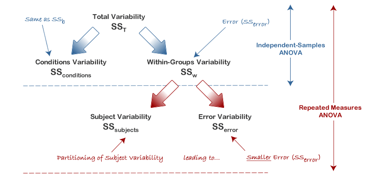

<sup>1</sup>

[^1]: https://statistics.laerd.com/statistical-guides/repeated-measures-anova-statistical-guide.php

## Example Sum of Squares partitioning

Imagine, we’d have a wine tasting and everyone of you tries six different wines and gives a rating from 1-10. This way, we would get the following data set:

| Subject | Wine1 | Wine2 | Wine3 | Wine4 | Wine5 | Wine6 | Mean_subject |
| --- | --- | --- | --- | --- | --- | --- | --- |
| Ecem | 5 | 6 | 7 | 6 | 3 | 5 | **5.333** |
| Ulkar | 7 | 8 | 8 | 7 | 6 | 6 | **7** |
| Francesco | 1 | 4 | 3 | 7 | 4 | 4 | **3.833** |
| Anna | 6 | 4 | 6 | 5 | 3 | 4 | **4.667** |
| Nikita | 8 | 7 | 4 | 6 | 9 | 3 | **6.167** |
| Zora | 2 | 3 | 2 | 10 | 4 | 3 | **4** |
| **Mean_wine** | **4.833** | **5.333** | **5** | **6.833** | **4.833** | **4.167** | **5.167** |

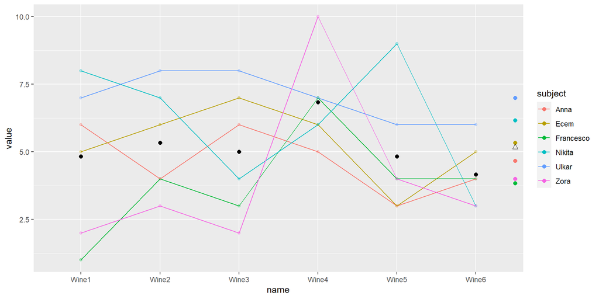

$$SS_{wine} = \sum_{i=1}^{n}n_i(\bar{x_i}-\bar{x})^2$$

For every wine, we subtract the grand mean (triangle) from each wine’s mean (black dots) (and multiply it by the number of subjects).

$$SS_{within} = \sum_{j=1}^{k}\sum_{i=1}^{n}(x_{ij}-\bar{x_j})^2$$

For the SSwithin, we subtract each individual data point from the mean of it’s wine group and add that up for all wines.

$$SS_{subjects} = k\sum_{i=1}^{n}(\bar{x_i}-\bar{x})^2$$

Here, we take *each subject’s mean* and subtract the grand average from it, and multiply it with the number of wines.
$$SS_{error} = SS_{within} - SS_{subjects}$$

We can then calculate the Mean Squares by dividing with the Degrees of Freedom. The MS are then used to calculate the F-Value:

$$MS_{wine} = \frac{SS_{wine}}{(k-1)}$$

$$MS_{error} = \frac{SS_{error}}{(n-1)(k-1)}$$

$$F=\frac{MS_{wine}}{MS_{error}}$$

## Calculating an ANOVA in R

There are a variety of functions to run an ANOVA in R. We will be using those from the `afex` package! (But any other is fine as well! The afex package has some advantages: The contrast definition and the Type 3 sum of squares etc.)

The main function is aov_car() - because it runs the `ANOVA()` function from the `car` package. `aov_ez()` and `aov_4()` are wrappers around `aov_car()`: They should reproduce the same result, but the input format/syntax differs.

```r
# library(tidyverse)
library(afex)
library(performance) # for checking assumptions
library(emmeans) # for contrasts/post-hoc tests
library(report) # handy tool to help you report your findings
```

Let’s use a bigger data set<sup>1</sup>:

With the `afex` package, we can use the same function to calculate one-way ANOVA, factorial ANOVA, repeated measures ANOVA, and mixed ANOVA. For this aim, we always have to specify the `Error()` variance.

E.g. one-way & factorial ANOVA:

```
Anova Table (Type 3 tests)

Response: T_1
     Effect     df  MSE          F  ges p.value
1 condition 2, 297 0.90 110.38 *** .426   <.001
---
Signif. codes:  0 '***' 0.001 '**' 0.01 '*' 0.05 '+' 0.1 ' ' 1
```

```
Anova Table (Type 3 tests)

Response: T_1
            Effect     df  MSE          F   ges p.value
1        condition 2, 294 0.90 108.73 ***  .425   <.001
2           gender 1, 294 0.90       0.05 <.001    .829
3 condition:gender 2, 294 0.90       0.78  .005    .457
---
Signif. codes:  0 '***' 0.001 '**' 0.01 '*' 0.05 '+' 0.1 ' ' 1
```

[^2]: Example from: https://tysonbarrett.com/jekyll/update/2018/03/14/afex_anova/ (but updated to newer packages)

Repeated measures ANOVA with afex

For a rmANOVA (in R with the afex package), we need the data to be in long format:

```r
z_long <- z %>%
  pivot_longer(cols = starts_with("T"),
               names_to = "timepoint")


# calculate ANOVA

aov_rm <- z_long %>%
  aov_car(value ~ 1 + Error(ID/timepoint),
          data = .)

# I prefer the formular notation:
aov_rm <- z_long %>%
  aov_4(value ~ 1 + (timepoint|ID),
        data = .)
aov_rm
```

```
Anova Table (Type 3 tests)

Response: value
     Effect           df  MSE    F   ges p.value
1 timepoint 1.99, 595.97 1.06 0.28 <.001    .754
---
Signif. codes:  0 '***' 0.001 '**' 0.01 '*' 0.05 '+' 0.1 ' ' 1

Sphericity correction method: GG
```

## Mixed ANOVA

We can simply extent our model by adding between-subjects variables:

```r
mixed_mod <- z_long %>%
  aov_4(value ~ condition + gender + (timepoint|ID),
        data = .)
mixed_mod
```

```
Anova Table (Type 3 tests)

Response: value
               Effect           df  MSE          F   ges p.value
1           condition       2, 296 0.94 304.08 ***  .387   <.001
2              gender       1, 296 0.94       0.32 <.001    .573
3           timepoint 1.99, 590.22 1.06       0.28 <.001    .756
4 condition:timepoint 3.99, 590.22 1.06       1.23  .006    .297
5    gender:timepoint 1.99, 590.22 1.06       0.24 <.001    .786
---
Signif. codes:  0 '***' 0.001 '**' 0.01 '*' 0.05 '+' 0.1 ' ' 1

Sphericity correction method: GG
```

## Checking assumptions

Unfortunately, we can’t use the `` performance``::check_model() `` (yet) to check the assumptions of model fit with `afex`. This means that we’d have to check the assumptions individually:

- continuous DV
- (outliers)
- sphericity (the variances of the differences between all levels must be equal)
- normality of residuals

```r
# sphericity
test_sphericity(mixed_mod)  # afex
```

```
OK: Data seems to be spherical (p > 0.641).
```

```r
check_sphericity(mixed_mod) # performance
```

```
OK: Data seems to be spherical (p > 0.641).
```

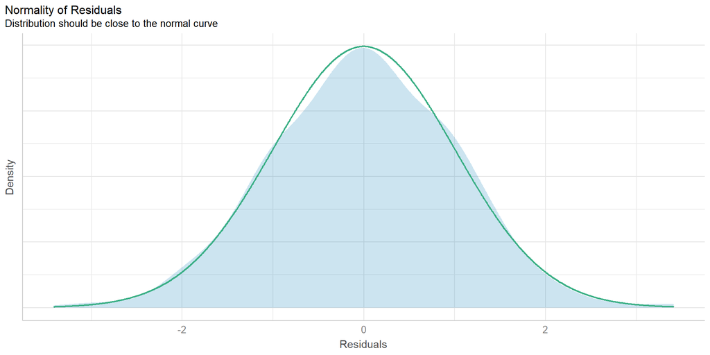

```r
# normality of residuals
# residuals(mixed_mod)
plot(check_normality(mixed_mod))
```